# Capstone P3

### TASK 1: Business Understanding

1. Clearly define the problem statement.
2. Identify:

a. Which is more costly? False Positive or False Negative? 3. Choose the most appropriate evaluation metric and justify your choice.

### 1.Defining problem statement

The objective of this project is to develop a ML model that predicts whether a credict card customer will misss the next months payment.This helps financial institutions identify high-risk customers early and take preventive actions to minimize financial losses.

### 2. Identify:

### a. Which is more costly? False Positive or False Negative?

**False Negative (more dangerous-Financial loss)

Actual situation: Customer misses payment,(High risk=1)

Model prediction: Customer is safe

**False Positive (less dangerous-Customer Dissatisfaction)

Actual situation: Customer pays normally,(low risk=0)

Model prediction: Customer is risky

False negatives are more costly because predicting a risky customer as low risk may lead to financial loss for the bank.False positives may only cause minor customer dissatisfaction.

### 3. Choose the most appropriate evaluation metric and justify your choice

Recall is chosen as the primary evaluation metric because it measures the model’s ability to correctly identify risky customers and minimize false negatives.

### TASK 2: Data Understanding & EDA

1. Dataset shape, data types
2. Check missing values
3. Class distribution (Target Variable) (Is it imbalanced?)
4. Visual analysis:

a. default payment next month rate by gender

b. default payment next month by education

c. Age distribution

d. Payment delay distribution

5. Correlation analysis

```python
import numpy as np
import pandas as pd
import matplotlib.pyplot as plt
import seaborn as sns
```

```python
bill_payments=pd.read_csv('credi bill payments.xls - Data.csv')
bill_payments.head()
```

|  | LIMIT_BAL | GENDER | EDUCATION | MARRIAGE | AGE | PAY_0 | PAY_2 | PAY_3 | PAY_4 | PAY_5 | ... | BILL_AMT4 | BILL_AMT5 | BILL_AMT6 | PAY_AMT1 | PAY_AMT2 | PAY_AMT3 | PAY_AMT4 | PAY_AMT5 | PAY_AMT6 | default payment next month |
| --- | --- | --- | --- | --- | --- | --- | --- | --- | --- | --- | --- | --- | --- | --- | --- | --- | --- | --- | --- | --- | --- |
| 0 | 20000 | 2 | 2 | 1 | 24 | 2 | 2 | -1 | -1 | -2 | ... | 0 | 0 | 0 | 0 | 689 | 0 | 0 | 0 | 0 | 1 |
| 1 | 120000 | 2 | 2 | 2 | 26 | -1 | 2 | 0 | 0 | 0 | ... | 3272 | 3455 | 3261 | 0 | 1000 | 1000 | 1000 | 0 | 2000 | 1 |
| 2 | 90000 | 2 | 2 | 2 | 34 | 0 | 0 | 0 | 0 | 0 | ... | 14331 | 14948 | 15549 | 1518 | 1500 | 1000 | 1000 | 1000 | 5000 | 0 |
| 3 | 50000 | 2 | 2 | 1 | 37 | 0 | 0 | 0 | 0 | 0 | ... | 28314 | 28959 | 29547 | 2000 | 2019 | 1200 | 1100 | 1069 | 1000 | 0 |
| 4 | 50000 | 1 | 2 | 1 | 57 | -1 | 0 | -1 | 0 | 0 | ... | 20940 | 19146 | 19131 | 2000 | 36681 | 10000 | 9000 | 689 | 679 | 0 |

5 rows × 24 columns

```python
bill_payments.columns
```

```
Index(['LIMIT_BAL', 'GENDER', 'EDUCATION', 'MARRIAGE', 'AGE', 'PAY_0', 'PAY_2',
       'PAY_3', 'PAY_4', 'PAY_5', 'PAY_6', 'BILL_AMT1', 'BILL_AMT2',
       'BILL_AMT3', 'BILL_AMT4', 'BILL_AMT5', 'BILL_AMT6', 'PAY_AMT1',
       'PAY_AMT2', 'PAY_AMT3', 'PAY_AMT4', 'PAY_AMT5', 'PAY_AMT6',
       'default payment next month'],
      dtype='object')
```

```python
# Dataset shape, data types
bill_payments.shape
```

```
(30000, 24)
```

```python
bill_payments.info()
```

```
<class 'pandas.core.frame.DataFrame'>
RangeIndex: 30000 entries, 0 to 29999
Data columns (total 24 columns):
 #   Column                      Non-Null Count  Dtype
---  ------                      --------------  -----
 0   LIMIT_BAL                   30000 non-null  int64
 1   GENDER                      30000 non-null  int64
 2   EDUCATION                   30000 non-null  int64
 3   MARRIAGE                    30000 non-null  int64
 4   AGE                         30000 non-null  int64
 5   PAY_0                       30000 non-null  int64
 6   PAY_2                       30000 non-null  int64
 7   PAY_3                       30000 non-null  int64
 8   PAY_4                       30000 non-null  int64
 9   PAY_5                       30000 non-null  int64
```

[output cut: 16 more lines]

```python
#Check missing values
bill_payments.isnull().sum()
```

```
LIMIT_BAL                     0
GENDER                        0
EDUCATION                     0
MARRIAGE                      0
AGE                           0
PAY_0                         0
PAY_2                         0
PAY_3                         0
PAY_4                         0
PAY_5                         0
PAY_6                         0
BILL_AMT1                     0
BILL_AMT2                     0
BILL_AMT3                     0
BILL_AMT4                     0
BILL_AMT5                     0
BILL_AMT6                     0
PAY_AMT1                      0
PAY_AMT2                      0
PAY_AMT3                      0
PAY_AMT4                      0
PAY_AMT5                      0
PAY_AMT6                      0
default payment next month    0
dtype: int64
```

```python
#Class distribution (Target Variable) (Is it imbalanced?)
bill_payments['default payment next month'].value_counts()
```

```
default payment next month
0    23364
1     6636
Name: count, dtype: int64
```

### Is it imbalanced?

yes,the givem dataset is imbalanced

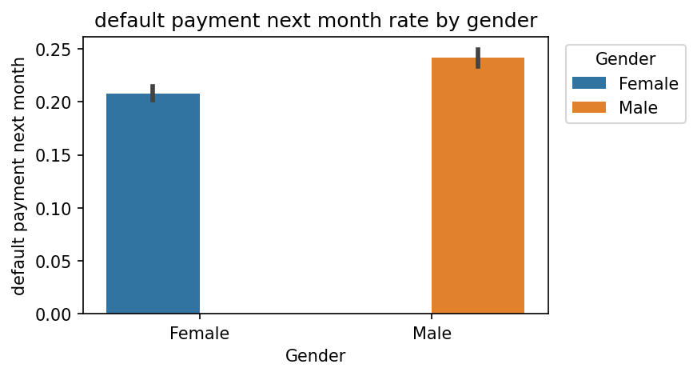

```python
# Visual analysis
#a)default payment next month rate by gender
bill_payments["GENDER"] = bill_payments["GENDER"].map({1: "Male", 2: "Female"})
plt.figure(figsize=(5,3),dpi=150)
sns.barplot(x="GENDER", y="default payment next month",hue="GENDER",data=bill_payments)
plt.title("default payment next month rate by gender")
plt.xlabel("Gender")
plt.legend(title="Gender", bbox_to_anchor=(1.02,1), loc="upper left");
plt.ylabel("default payment next month");
```

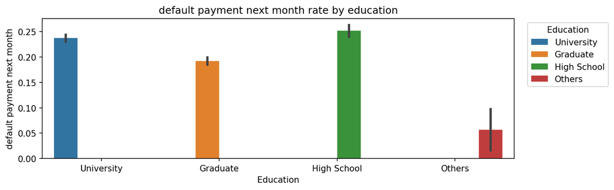

```python
#default payment next month by education
bill_payments["EDUCATION"] = bill_payments["EDUCATION"].map({1:"Graduate", 2:"University", 3:"High School", 4:"Others"})
plt.figure(figsize=(10,3),dpi=150)
sns.barplot(x="EDUCATION", y="default payment next month",hue="EDUCATION",data=bill_payments)
plt.title("default payment next month rate by education")
plt.xlabel("Education")
plt.legend(title="Education", bbox_to_anchor=(1.02,1), loc="upper left");
plt.ylabel("default payment next month");
```

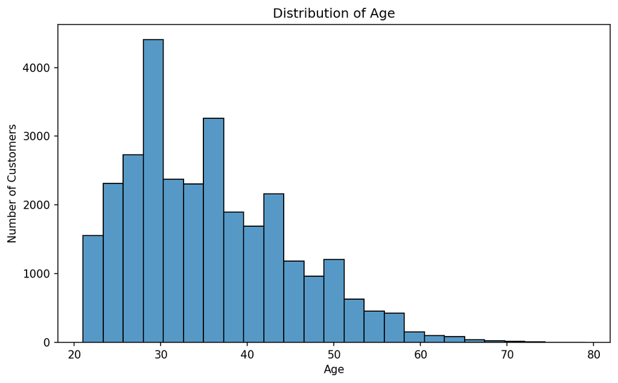

```python
#Age distribution
plt.figure(figsize=(8,5),dpi=150)
sns.histplot(data=bill_payments,bins=25,x="AGE");
plt.title("Distribution of Age")
plt.xlabel("Age")
plt.ylabel("Number of Customers")
plt.tight_layout()
plt.show()
```

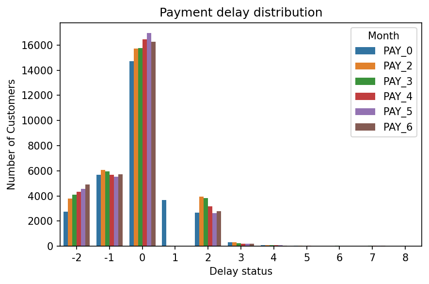

```python
#Payment delay distribution
pay_cols=['PAY_0','PAY_2','PAY_3','PAY_4','PAY_5','PAY_6']
delay_data=bill_payments[pay_cols].melt(var_name="Month", value_name="Delay_Status")
plt.figure(figsize=(6,4),dpi=150)
sns.countplot(x="Delay_Status", hue="Month", data=delay_data)
plt.title("Payment delay distribution")
plt.xlabel("Delay status")
plt.ylabel("Number of Customers")
plt.tight_layout()
plt.show()
#Delay Value	Meaning
#-2	            No credit card usage / no bill generated
#-1             Paid on time
#1	           1 month payment delay
#2	           2 months payment delay
#3	           3 months delay
#4+	           Longer payment delays
```

```python
#Correlation analysis
bill_payments["GENDER"] = bill_payments["GENDER"].map({ "Male":1,  "Female":2}).astype("Int64")
bill_payments["EDUCATION"] = bill_payments["EDUCATION"].map({
    "Graduate":1,
    "University":2,
    "High School":3,
    "Others":4
}).astype("Int64")
correlation=bill_payments.corr()
correlation
```

|  | LIMIT_BAL | GENDER | EDUCATION | MARRIAGE | AGE | PAY_0 | PAY_2 | PAY_3 | PAY_4 | PAY_5 | ... | BILL_AMT4 | BILL_AMT5 | BILL_AMT6 | PAY_AMT1 | PAY_AMT2 | PAY_AMT3 | PAY_AMT4 | PAY_AMT5 | PAY_AMT6 | default payment next month |
| --- | --- | --- | --- | --- | --- | --- | --- | --- | --- | --- | --- | --- | --- | --- | --- | --- | --- | --- | --- | --- | --- |
| LIMIT_BAL | 1.000000 | 0.024755 | -0.244360 | -0.108139 | 0.144713 | -0.271214 | -0.296382 | -0.286123 | -0.267460 | -0.249411 | ... | 0.293988 | 0.295562 | 0.290389 | 0.195236 | 0.178408 | 0.210167 | 0.203242 | 0.217202 | 0.219595 | -0.153520 |
| GENDER | 0.024755 | 1.000000 | 0.012584 | -0.031389 | -0.090874 | -0.057643 | -0.070771 | -0.066096 | -0.060173 | -0.055064 | ... | -0.021880 | -0.017005 | -0.016733 | -0.000242 | -0.001391 | -0.008597 | -0.002229 | -0.001667 | -0.002766 | -0.039961 |
| EDUCATION | -0.244360 | 0.012584 | 1.000000 | -0.153509 | 0.187570 | 0.123181 | 0.142972 | 0.136138 | 0.128501 | 0.115204 | ... | -0.015327 | -0.019113 | -0.016165 | -0.045338 | -0.038943 | -0.052136 | -0.043463 | -0.049799 | -0.053887 | 0.048248 |
| MARRIAGE | -0.108139 | -0.031389 | -0.153509 | 1.000000 | -0.414170 | 0.019917 | 0.024199 | 0.032688 | 0.033122 | 0.035629 | ... | -0.023344 | -0.025393 | -0.021207 | -0.005979 | -0.008093 | -0.003541 | -0.012659 | -0.001205 | -0.006641 | -0.024339 |
| AGE | 0.144713 | -0.090874 | 0.187570 | -0.414170 | 1.000000 | -0.039447 | -0.050148 | -0.053048 | -0.049722 | -0.053826 | ... | 0.051353 | 0.049345 | 0.047613 | 0.026147 | 0.021785 | 0.029247 | 0.021379 | 0.022850 | 0.019478 | 0.013890 |
| PAY_0 | -0.271214 | -0.057643 | 0.123181 | 0.019917 | -0.039447 | 1.000000 | 0.672164 | 0.574245 | 0.538841 | 0.509426 | ... | 0.179125 | 0.180635 | 0.176980 | -0.079269 | -0.070101 | -0.070561 | -0.064005 | -0.058190 | -0.058673 | 0.324794 |
| PAY_2 | -0.296382 | -0.070771 | 0.142972 | 0.024199 | -0.050148 | 0.672164 | 1.000000 | 0.766552 | 0.662067 | 0.622780 | ... | 0.222237 | 0.221348 | 0.219403 | -0.080701 | -0.058990 | -0.055901 | -0.046858 | -0.037093 | -0.036500 | 0.263551 |
| PAY_3 | -0.286123 | -0.066096 | 0.136138 | 0.032688 | -0.053048 | 0.574245 | 0.766552 | 1.000000 | 0.777359 | 0.686775 | ... | 0.227202 | 0.225145 | 0.222327 | 0.001295 | -0.066793 | -0.053311 | -0.046067 | -0.035863 | -0.035861 | 0.235253 |
| PAY_4 | -0.267460 | -0.060173 | 0.128501 | 0.033122 | -0.049722 | 0.538841 | 0.662067 | 0.777359 | 1.000000 | 0.819835 | ... | 0.245917 | 0.242902 | 0.239154 | -0.009362 | -0.001944 | -0.069235 | -0.043461 | -0.033590 | -0.026565 | 0.216614 |
| PAY_5 | -0.249411 | -0.055064 | 0.115204 | 0.035629 | -0.053826 | 0.509426 | 0.622780 | 0.686775 | 0.819835 | 1.000000 | ... | 0.271915 | 0.269783 | 0.262509 | -0.006089 | -0.003191 | 0.009062 | -0.058299 | -0.033337 | -0.023027 | 0.204149 |
| PAY_6 | -0.235195 | -0.044008 | 0.102788 | 0.034345 | -0.048773 | 0.474553 | 0.575501 | 0.632684 | 0.716449 | 0.816900 | ... | 0.266356 | 0.290894 | 0.285091 | -0.001496 | -0.005223 | 0.005834 | 0.019018 | -0.046434 | -0.025299 | 0.186866 |
| BILL_AMT1 | 0.285430 | -0.033642 | 0.004191 | -0.023472 | 0.056239 | 0.187068 | 0.234887 | 0.208473 | 0.202812 | 0.206684 | ... | 0.860272 | 0.829779 | 0.802650 | 0.140277 | 0.099355 | 0.156887 | 0.158303 | 0.167026 | 0.179341 | -0.019644 |
| BILL_AMT2 | 0.278314 | -0.031183 | 0.000512 | -0.021602 | 0.054283 | 0.189859 | 0.235257 | 0.237295 | 0.225816 | 0.226913 | ... | 0.892482 | 0.859778 | 0.831594 | 0.280365 | 0.100851 | 0.150718 | 0.147398 | 0.157957 | 0.174256 | -0.014193 |
| BILL_AMT3 | 0.283236 | -0.024563 | -0.004419 | -0.024909 | 0.053710 | 0.179785 | 0.224146 | 0.227494 | 0.244983 | 0.243335 | ... | 0.923969 | 0.883910 | 0.853320 | 0.244335 | 0.316936 | 0.130011 | 0.143405 | 0.179712 | 0.182326 | -0.014076 |
| BILL_AMT4 | 0.293988 | -0.021880 | -0.015327 | -0.023344 | 0.051353 | 0.179125 | 0.222237 | 0.227202 | 0.245917 | 0.271915 | ... | 1.000000 | 0.940134 | 0.900941 | 0.233012 | 0.207564 | 0.300023 | 0.130191 | 0.160433 | 0.177637 | -0.010156 |
| BILL_AMT5 | 0.295562 | -0.017005 | -0.019113 | -0.025393 | 0.049345 | 0.180635 | 0.221348 | 0.225145 | 0.242902 | 0.269783 | ... | 0.940134 | 1.000000 | 0.946197 | 0.217031 | 0.181246 | 0.252305 | 0.293118 | 0.141574 | 0.164184 | -0.006760 |
| BILL_AMT6 | 0.290389 | -0.016733 | -0.016165 | -0.021207 | 0.047613 | 0.176980 | 0.219403 | 0.222327 | 0.239154 | 0.262509 | ... | 0.900941 | 0.946197 | 1.000000 | 0.199965 | 0.172663 | 0.233770 | 0.250237 | 0.307729 | 0.115494 | -0.005372 |
| PAY_AMT1 | 0.195236 | -0.000242 | -0.045338 | -0.005979 | 0.026147 | -0.079269 | -0.080701 | 0.001295 | -0.009362 | -0.006089 | ... | 0.233012 | 0.217031 | 0.199965 | 1.000000 | 0.285576 | 0.252191 | 0.199558 | 0.148459 | 0.185735 | -0.072929 |
| PAY_AMT2 | 0.178408 | -0.001391 | -0.038943 | -0.008093 | 0.021785 | -0.070101 | -0.058990 | -0.066793 | -0.001944 | -0.003191 | ... | 0.207564 | 0.181246 | 0.172663 | 0.285576 | 1.000000 | 0.244770 | 0.180107 | 0.180908 | 0.157634 | -0.058579 |
| PAY_AMT3 | 0.210167 | -0.008597 | -0.052136 | -0.003541 | 0.029247 | -0.070561 | -0.055901 | -0.053311 | -0.069235 | 0.009062 | ... | 0.300023 | 0.252305 | 0.233770 | 0.252191 | 0.244770 | 1.000000 | 0.216325 | 0.159214 | 0.162740 | -0.056250 |
| PAY_AMT4 | 0.203242 | -0.002229 | -0.043463 | -0.012659 | 0.021379 | -0.064005 | -0.046858 | -0.046067 | -0.043461 | -0.058299 | ... | 0.130191 | 0.293118 | 0.250237 | 0.199558 | 0.180107 | 0.216325 | 1.000000 | 0.151830 | 0.157834 | -0.056827 |
| PAY_AMT5 | 0.217202 | -0.001667 | -0.049799 | -0.001205 | 0.022850 | -0.058190 | -0.037093 | -0.035863 | -0.033590 | -0.033337 | ... | 0.160433 | 0.141574 | 0.307729 | 0.148459 | 0.180908 | 0.159214 | 0.151830 | 1.000000 | 0.154896 | -0.055124 |
| PAY_AMT6 | 0.219595 | -0.002766 | -0.053887 | -0.006641 | 0.019478 | -0.058673 | -0.036500 | -0.035861 | -0.026565 | -0.023027 | ... | 0.177637 | 0.164184 | 0.115494 | 0.185735 | 0.157634 | 0.162740 | 0.157834 | 0.154896 | 1.000000 | -0.053183 |
| default payment next month | -0.153520 | -0.039961 | 0.048248 | -0.024339 | 0.013890 | 0.324794 | 0.263551 | 0.235253 | 0.216614 | 0.204149 | ... | -0.010156 | -0.006760 | -0.005372 | -0.072929 | -0.058579 | -0.056250 | -0.056827 | -0.055124 | -0.053183 | 1.000000 |

24 rows × 24 columns

```python
bill_payments.corr()["default payment next month"].sort_values(ascending=False)
```

```
default payment next month    1.000000
PAY_0                         0.324794
PAY_2                         0.263551
PAY_3                         0.235253
PAY_4                         0.216614
PAY_5                         0.204149
PAY_6                         0.186866
EDUCATION                     0.048248
AGE                           0.013890
BILL_AMT6                    -0.005372
BILL_AMT5                    -0.006760
BILL_AMT4                    -0.010156
BILL_AMT3                    -0.014076
BILL_AMT2                    -0.014193
BILL_AMT1                    -0.019644
MARRIAGE                     -0.024339
GENDER                       -0.039961
PAY_AMT6                     -0.053183
PAY_AMT5                     -0.055124
PAY_AMT3                     -0.056250
PAY_AMT4                     -0.056827
PAY_AMT2                     -0.058579
PAY_AMT1                     -0.072929
LIMIT_BAL                    -0.153520
Name: default payment next month, dtype: float64
```

Default payment next month is highly correlated with PAY_0

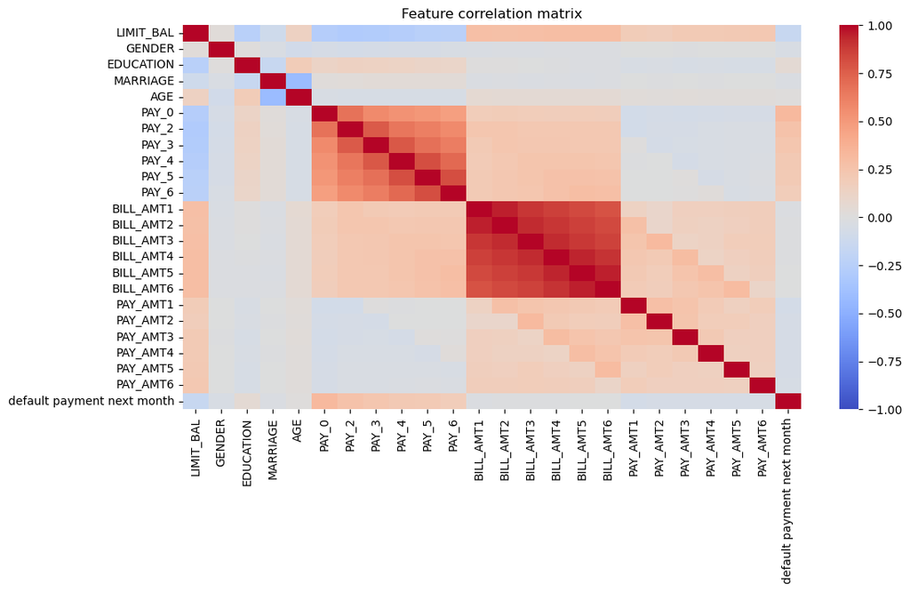

```python
plt.figure(figsize=(12,6))
sns.heatmap(correlation,cmap='coolwarm',fmt='.2f',vmin=-1,vmax=1)
plt.title("Feature correlation matrix" )
plt.show()
```

### TASK 3: Data Preprocessing

1. Handle invalid or unusual values (if any)
2. Encoding (if needed)
3. Apply scaling where necessary
4. Train-test split

```python
bill_payments.head()
```

|  | LIMIT_BAL | GENDER | EDUCATION | MARRIAGE | AGE | PAY_0 | PAY_2 | PAY_3 | PAY_4 | PAY_5 | ... | BILL_AMT4 | BILL_AMT5 | BILL_AMT6 | PAY_AMT1 | PAY_AMT2 | PAY_AMT3 | PAY_AMT4 | PAY_AMT5 | PAY_AMT6 | default payment next month |
| --- | --- | --- | --- | --- | --- | --- | --- | --- | --- | --- | --- | --- | --- | --- | --- | --- | --- | --- | --- | --- | --- |
| 0 | 20000 | 2 | 2 | 1 | 24 | 2 | 2 | -1 | -1 | -2 | ... | 0 | 0 | 0 | 0 | 689 | 0 | 0 | 0 | 0 | 1 |
| 1 | 120000 | 2 | 2 | 2 | 26 | -1 | 2 | 0 | 0 | 0 | ... | 3272 | 3455 | 3261 | 0 | 1000 | 1000 | 1000 | 0 | 2000 | 1 |
| 2 | 90000 | 2 | 2 | 2 | 34 | 0 | 0 | 0 | 0 | 0 | ... | 14331 | 14948 | 15549 | 1518 | 1500 | 1000 | 1000 | 1000 | 5000 | 0 |
| 3 | 50000 | 2 | 2 | 1 | 37 | 0 | 0 | 0 | 0 | 0 | ... | 28314 | 28959 | 29547 | 2000 | 2019 | 1200 | 1100 | 1069 | 1000 | 0 |
| 4 | 50000 | 1 | 2 | 1 | 57 | -1 | 0 | -1 | 0 | 0 | ... | 20940 | 19146 | 19131 | 2000 | 36681 | 10000 | 9000 | 689 | 679 | 0 |

5 rows × 24 columns

```python
#Handle invalid or unusual values (if any)
for col in bill_payments.select_dtypes(include=["int64","float64"]):
    print(col, bill_payments[col].min(), bill_payments[col].max())
```

```
LIMIT_BAL 10000 1000000
GENDER 1 2
EDUCATION 1 4
MARRIAGE 0 3
AGE 21 79
PAY_0 -2 8
PAY_2 -2 8
PAY_3 -2 8
PAY_4 -2 8
PAY_5 -2 8
PAY_6 -2 8
BILL_AMT1 -165580 964511
BILL_AMT2 -69777 983931
BILL_AMT3 -157264 1664089
BILL_AMT4 -170000 891586
BILL_AMT5 -81334 927171
BILL_AMT6 -339603 961664
PAY_AMT1 0 873552
PAY_AMT2 0 1684259
PAY_AMT3 0 896040
PAY_AMT4 0 621000
PAY_AMT5 0 426529
PAY_AMT6 0 528666
default payment next month 0 1
```

```python
bill_payments["EDUCATION"].fillna(bill_payments["EDUCATION"].mode()[0], inplace=True)
```

```python
#handling marriage data according to dataset description
bill_payments['MARRIAGE'].unique()
```

```
array([1, 2, 3, 0], dtype=int64)
```

```python
bill_payments['MARRIAGE'].replace(0,3,inplace=True)
bill_payments['MARRIAGE'].unique()
```

```
array([1, 2, 3], dtype=int64)
```

```python
pay_cols = ['PAY_0','PAY_2','PAY_3','PAY_4','PAY_5','PAY_6']
for col in pay_cols:
    print(col, bill_payments[col].unique())
```

```
PAY_0 [ 2 -1  0 -2  1  3  4  8  7  5  6]
PAY_2 [ 2  0 -1 -2  3  5  7  4  1  6  8]
PAY_3 [-1  0  2 -2  3  4  6  7  1  5  8]
PAY_4 [-1  0 -2  2  3  4  5  7  6  1  8]
PAY_5 [-2  0 -1  2  3  5  4  7  8  6]
PAY_6 [-2  2  0 -1  3  6  4  7  8  5]
```

```python
for col in pay_cols:
     bill_payments[col].replace(-2,-1,inplace=True)
```

```python
for col in pay_cols:
    print(col, bill_payments[col].unique())
```

```
PAY_0 [ 2 -1  0  1  3  4  8  7  5  6]
PAY_2 [ 2  0 -1  3  5  7  4  1  6  8]
PAY_3 [-1  0  2  3  4  6  7  1  5  8]
PAY_4 [-1  0  2  3  4  5  7  6  1  8]
PAY_5 [-1  0  2  3  5  4  7  8  6]
PAY_6 [-1  2  0  3  6  4  7  8  5]
```

### Encoding (if needed)

No encoding is required

### Apply scaling where necessary

Scaling is not necessary for all models of the classification.

Scaling is required for :

a)Logistic Regression

b)KNN

c)SVM

These algorithms depend on distance or gradient calculations, so scaling improves their performance.

Models that do not require scaling:

a) Decision Tree

b) Random Forest

c) AdaBoost

d) XGBoost

e) LightGBM

f) CatBoost

Tree-based models split data by thresholds and are not sensitive to feature scale.

```python
# Train-test split
X=bill_payments.drop('default payment next month',axis=1)
y=bill_payments['default payment next month']
```

```python
y.head()
```

```
0    1
1    1
2    0
3    0
4    0
Name: default payment next month, dtype: int64
```

```python
from sklearn.model_selection import train_test_split
X_train,X_test,y_train,y_test=train_test_split(X,y,test_size=0.3,random_state=101)
```

### TASK 4: Models Building

1. Build the following models using default parameters:

a. Logistic Regression

b. KNN

c. SVM

d. Decision Tree

e. Random Forest

f. AdaBoost

g. XGBoost

h. LightGBM

i. CatBoost

2. Evaluate each using:

a. Accuracy

b. Precision

c. Recall

d. F1 Score

```python
#Build the following models using default parameters
# a)Logistic Regression
# Feature Scaling
from sklearn.preprocessing import StandardScaler
scaler=StandardScaler()
```

```python
# scale features
X_train_scaled=scaler.fit_transform(X_train)
X_test_scaled=scaler.transform(X_test)
```

```python
X_train_scaled[:10]
```

```
array([[-1.06533126,  0.80833973,  0.25385171, -1.06672953, -0.1639338 ,
        -1.0796122 , -0.95264732,  1.95410948,  0.07319354,  0.11989307,
         0.13462474, -0.68964877, -0.67782455, -0.6669585 , -0.65143036,
        -0.64084394, -0.62874495, -0.27769218, -0.23989221, -0.2118446 ,
        -0.28706816, -0.28350864, -0.29194625],
       [ 0.3216164 ,  0.80833973,  1.6645122 ,  0.84987897,  1.13831752,
         0.92665798,  1.92765124,  0.02516809,  0.07319354, -0.93312007,
        -0.91168152, -0.61648108, -0.61365656, -0.38832922, -0.40588145,
        -0.62620654, -0.64799932, -0.33468939,  0.44962638, -0.28899898,
        -0.16379685, -0.29364408, -0.07136759],
       [-0.68006802,  0.80833973, -1.15680878,  0.84987897, -0.81505947,
        -0.07647711,  0.0074522 ,  0.02516809,  0.07319354,  0.11989307,
         0.13462474,  0.26216745,  0.31823515,  0.38053043,  0.49157281,
         0.56193831,  0.59962404, -0.15064671, -0.10046676, -0.10969655,
        -0.13217228, -0.12414637, -0.13202672],
       [ 0.55277434,  0.80833973, -1.15680878,  0.84987897,  0.05310808,
         0.92665798, -0.95264732,  0.02516809,  0.07319354,  0.11989307,
         0.13462474, -0.69521249, -0.43978426, -0.41110538, -0.40438147,
        -0.34791632, -0.30030564,  0.70402279, -0.16022052, -0.18033084,
        -0.18380424, -0.11777188, -0.18165692],
       [-0.60301537,  0.80833973,  0.25385171, -1.06672953, -0.27245475,
        -0.07647711,  0.0074522 ,  0.02516809,  0.07319354,  0.11989307,
        -0.91168152, -0.64354161, -0.57213774, -0.54719078, -0.49298876,
        -0.64451962, -0.65200995, -0.04670042, -0.18870315, -0.12599677,
        -0.23614614, -0.3090066 ,  0.19509142],
       [-0.14069949,  0.80833973, -1.15680878,  0.84987897, -0.92358041,
         1.92979307,  1.92765124,  1.95410948,  2.07849593,  0.11989307,
         0.13462474, -0.48572683, -0.43681663, -0.40921927, -0.39488673,
        -0.35802854, -0.32892926, -0.1621963 , -0.20005636, -0.28899898,
        -0.24834419, -0.24526169, -0.23680158],
       [ 0.3216164 ,  0.80833973,  0.25385171,  0.84987897, -0.92358041,
        -0.07647711,  0.0074522 ,  0.02516809,  0.07319354,  0.11989307,
         0.13462474, -0.0716153 , -0.14649286, -0.25035771, -0.43569556,
        -0.46014725, -0.47669033, -0.22277389, -0.11903026, -0.12599677,
        -0.11926429, -0.11777188, -0.28687294],
       [-0.68006802,  0.80833973,  1.6645122 ,  0.84987897, -0.48949664,
        -0.07647711,  0.0074522 ,  0.02516809,  2.07849593,  2.22591935,
         2.22723727, -0.22656023, -0.19118928, -0.10339863, -0.04314824,
        -0.01078247,  0.09055643, -0.21994424, -0.03274583, -0.19663106,
        -0.31288414,  0.04159039, -0.29194625],
       [-0.75712067,  0.80833973, -1.15680878, -1.06672953,  1.02979657,
         0.92665798,  1.92765124,  1.95410948,  0.07319354,  0.11989307,
         0.13462474,  0.24959154,  0.29870758,  0.25850509,  0.22726637,
        -0.0767651 , -0.18720909, -0.1621963 , -0.23989221, -0.12599677,
         0.07067679,  0.32844246, -0.1679259 ],
       [-0.44891008,  0.80833973,  0.25385171,  0.84987897, -1.24914324,
        -0.07647711,  0.0074522 ,  0.02516809,  0.07319354,  0.11989307,
         0.13462474,  0.64282896,  0.60756504,  0.44260046,  0.40004286,
         0.49572697,  0.61000842, -0.15064671, -0.10046676, -0.12599677,
        -0.08699431,  0.13720774, -0.12651226]])
```

### LogisticRegression (Train the model)

```python
from sklearn.linear_model import LogisticRegression
logistic_M1=LogisticRegression()
logistic_M1.fit(X_train_scaled,y_train)
```

```
LogisticRegression()
```

```python
y_pred=logistic_M1.predict(X_test_scaled)
y_pred[:10]
```

```
array([0, 0, 0, 0, 0, 0, 0, 0, 0, 0], dtype=int64)
```

```python
y_test[:10]
```

```
6015     1
28660    0
12498    0
22957    0
14848    0
21298    0
3798     0
21714    0
8362     1
14399    0
Name: default payment next month, dtype: int64
```

```python
## model evaluation
from sklearn.metrics import confusion_matrix,accuracy_score,classification_report
```

```python
confusion_matrix(y_test,y_pred)
```

```
array([[6853,  205],
       [1429,  513]], dtype=int64)
```

```python
accuracy_score(y_test,y_pred)
```

```
0.8184444444444444
```

```python
print(classification_report(y_test,y_pred))
```

```
              precision    recall  f1-score   support

           0       0.83      0.97      0.89      7058
           1       0.71      0.26      0.39      1942

    accuracy                           0.82      9000
   macro avg       0.77      0.62      0.64      9000
weighted avg       0.80      0.82      0.78      9000
```

### KNN

```python
from sklearn.neighbors import KNeighborsClassifier
```

```python
KNN_M2=KNeighborsClassifier()
```

```python
KNN_M2.fit(X_train_scaled,y_train)
```

```
KNeighborsClassifier()
```

```python
y_pred_2=KNN_M2.predict(X_test_scaled)
y_pred_2[:10]
```

```
array([0, 0, 0, 0, 0, 0, 0, 0, 0, 0], dtype=int64)
```

```python
y_test[:10]
```

```
6015     1
28660    0
12498    0
22957    0
14848    0
21298    0
3798     0
21714    0
8362     1
14399    0
Name: default payment next month, dtype: int64
```

```python
## model evaluation
from sklearn.metrics import confusion_matrix,accuracy_score,classification_report
```

```python
confusion_matrix(y_test,y_pred_2)
```

```
array([[6467,  591],
       [1278,  664]], dtype=int64)
```

```python
accuracy_score(y_test,y_pred_2)
```

```
0.7923333333333333
```

```python
print(classification_report(y_test,y_pred))
```

```
              precision    recall  f1-score   support

           0       0.83      0.97      0.89      7058
           1       0.71      0.26      0.39      1942

    accuracy                           0.82      9000
   macro avg       0.77      0.62      0.64      9000
weighted avg       0.80      0.82      0.78      9000
```

### SVM

```python
from sklearn.svm import SVC
```

```python
svm_M3=SVC()
```

```python
svm_M3.fit(X_train_scaled,y_train)
```

```
SVC()
```

```python
y_pred_3=svm_M3.predict(X_test_scaled)
y_pred_3[:3]
```

```
array([0, 0, 0], dtype=int64)
```

```python
#model Evaluation
from sklearn.metrics import confusion_matrix,accuracy_score,classification_report
```

```python
confusion_matrix(y_test,y_pred_3)
```

```
array([[6774,  284],
       [1295,  647]], dtype=int64)
```

```python
accuracy_score(y_test,y_pred_3)
```

```
0.8245555555555556
```

```python
print(classification_report(y_test,y_pred_3))
```

```
              precision    recall  f1-score   support

           0       0.84      0.96      0.90      7058
           1       0.69      0.33      0.45      1942

    accuracy                           0.82      9000
   macro avg       0.77      0.65      0.67      9000
weighted avg       0.81      0.82      0.80      9000
```

### Decision Tree

```python
from sklearn.tree import DecisionTreeClassifier
```

```python
Decision_tree_M4=DecisionTreeClassifier()
Decision_tree_M4.fit(X_train,y_train)
```

```
DecisionTreeClassifier()
```

```python
y_pred_4=Decision_tree_M4.predict(X_test)
y_pred_4[:10]
```

```
array([0, 0, 0, 0, 0, 0, 0, 0, 0, 0], dtype=int64)
```

```python
# model Evaluation
from sklearn.metrics import confusion_matrix,accuracy_score,classification_report
```

```python
confusion_matrix(y_test,y_pred_4)
```

```
array([[5749, 1309],
       [1125,  817]], dtype=int64)
```

```python
accuracy_score(y_test,y_pred_4)
```

```
0.7295555555555555
```

```python
print(classification_report(y_test,y_pred_4))
```

```
              precision    recall  f1-score   support

           0       0.84      0.81      0.83      7058
           1       0.38      0.42      0.40      1942

    accuracy                           0.73      9000
   macro avg       0.61      0.62      0.61      9000
weighted avg       0.74      0.73      0.73      9000
```

### Random Forest

```python
from sklearn.ensemble import RandomForestClassifier
```

```python
Random_forest_M5=RandomForestClassifier()
```

```python
Random_forest_M5.fit(X_train,y_train)
```

```
RandomForestClassifier()
```

```python
y_pred_5=Random_forest_M5.predict(X_test)
y_pred_5[:5]
```

```
array([0, 0, 0, 0, 0], dtype=int64)
```

```python
# model Evaluation
from sklearn.metrics import confusion_matrix,accuracy_score,classification_report
```

```python
confusion_matrix(y_test,y_pred_5)
```

```
array([[6648,  410],
       [1238,  704]], dtype=int64)
```

```python
accuracy_score(y_test,y_pred_5)
```

```
0.8168888888888889
```

```python
print(classification_report(y_test,y_pred_5))
```

```
              precision    recall  f1-score   support

           0       0.84      0.94      0.89      7058
           1       0.63      0.36      0.46      1942

    accuracy                           0.82      9000
   macro avg       0.74      0.65      0.68      9000
weighted avg       0.80      0.82      0.80      9000
```

### AdaBoost

```python
from sklearn.ensemble import AdaBoostClassifier
```

```python
AdaBoost_M6=AdaBoostClassifier()
```

```python
AdaBoost_M6.fit(X_train,y_train)
```

```
AdaBoostClassifier()
```

```python
y_pred_6=AdaBoost_M6.predict(X_test)
y_pred_6[:10]
```

```
array([0, 0, 0, 0, 0, 0, 0, 0, 0, 0], dtype=int64)
```

```python
# Model Evaluation
from sklearn.metrics import confusion_matrix,accuracy_score,classification_report
```

```python
confusion_matrix(y_test,y_pred_6)
```

```
array([[6778,  280],
       [1332,  610]], dtype=int64)
```

```python
accuracy_score(y_test,y_pred_6)
```

```
0.8208888888888889
```

```python
print(classification_report(y_test,y_pred_6))
```

```
              precision    recall  f1-score   support

           0       0.84      0.96      0.89      7058
           1       0.69      0.31      0.43      1942

    accuracy                           0.82      9000
   macro avg       0.76      0.64      0.66      9000
weighted avg       0.80      0.82      0.79      9000
```

### XGBoost

```python
from xgboost import XGBClassifier
```

```python
XGB_M7=XGBClassifier()
```

```python
XGB_M7.fit(X_train,y_train)
```

```
XGBClassifier(base_score=None, booster=None, callbacks=None,
              colsample_bylevel=None, colsample_bynode=None,
              colsample_bytree=None, device=None, early_stopping_rounds=None,
              enable_categorical=False, eval_metric=None, feature_types=None,
              gamma=None, grow_policy=None, importance_type=None,
              interaction_constraints=None, learning_rate=None, max_bin=None,
              max_cat_threshold=None, max_cat_to_onehot=None,
              max_delta_step=None, max_depth=None, max_leaves=None,
              min_child_weight=None, missing=nan, monotone_constraints=None,
              multi_strategy=None, n_estimators=None, n_jobs=None,
              num_parallel_tree=None, random_state=None, ...)
```

```python
y_pred_7=XGB_M7.predict(X_test)
y_pred_7
```

```
array([0, 0, 0, ..., 0, 0, 0])
```

```python
# Model Evaluation
from sklearn.metrics import confusion_matrix,accuracy_score,classification_report
```

```python
confusion_matrix(y_test,y_pred_7)
```

```
array([[6612,  446],
       [1244,  698]], dtype=int64)
```

```python
accuracy_score(y_test,y_pred_7)
```

```
0.8122222222222222
```

```python
print(classification_report(y_test,y_pred_7))
```

```
              precision    recall  f1-score   support

           0       0.84      0.94      0.89      7058
           1       0.61      0.36      0.45      1942

    accuracy                           0.81      9000
   macro avg       0.73      0.65      0.67      9000
weighted avg       0.79      0.81      0.79      9000
```

### LightGBM

```python
from lightgbm import LGBMClassifier
```

```python
LGBM_M8=LGBMClassifier()
```

```python
LGBM_M8.fit(X_train,y_train)
```

```
[LightGBM] [Info] Number of positive: 4694, number of negative: 16306
[LightGBM] [Info] Auto-choosing col-wise multi-threading, the overhead of testing was 0.001454 seconds.
You can set `force_col_wise=true` to remove the overhead.
[LightGBM] [Info] Total Bins 3256
[LightGBM] [Info] Number of data points in the train set: 21000, number of used features: 23
[LightGBM] [Info] [binary:BoostFromScore]: pavg=0.223524 -> initscore=-1.245248
[LightGBM] [Info] Start training from score -1.245248
```

```
LGBMClassifier()
```

```python
y_pred_8=LGBM_M8.predict(X_test)
y_pred_8[:10]
```

```
array([0, 0, 0, 0, 0, 0, 0, 0, 0, 0], dtype=int64)
```

```python
# Model Evaluation
from sklearn.metrics import confusion_matrix,accuracy_score,classification_report
```

```python
confusion_matrix(y_test,y_pred_8)
```

```
array([[6705,  353],
       [1230,  712]], dtype=int64)
```

```python
accuracy_score(y_test,y_pred_8)
```

```
0.8241111111111111
```

```python
print(classification_report(y_test,y_pred_8))
```

```
              precision    recall  f1-score   support

           0       0.84      0.95      0.89      7058
           1       0.67      0.37      0.47      1942

    accuracy                           0.82      9000
   macro avg       0.76      0.66      0.68      9000
weighted avg       0.81      0.82      0.80      9000
```

### CatBoost

```python
from catboost import CatBoostClassifier
```

```python
cat_boost_M9=CatBoostClassifier()
```

```python
cat_boost_M9.fit(X_train,y_train)
```

[output not shown]

[output cut: 946 more lines]

[output not shown]

```
CatBoostClassifier()
```

```python
y_pred_9=LGBM_M8.predict(X_test)
y_pred_9[:10]
```

```
array([0, 0, 0, 0, 0, 0, 0, 0, 0, 0], dtype=int64)
```

```python
# Model Evaluation
from sklearn.metrics import confusion_matrix,accuracy_score,classification_report
```

```python
confusion_matrix(y_test,y_pred_9)
```

```
array([[6705,  353],
       [1230,  712]], dtype=int64)
```

```python
accuracy_score(y_test,y_pred_8)
```

```
0.8241111111111111
```

```python
print(classification_report(y_test,y_pred_8))
```

```
              precision    recall  f1-score   support

           0       0.84      0.95      0.89      7058
           1       0.67      0.37      0.47      1942

    accuracy                           0.82      9000
   macro avg       0.76      0.66      0.68      9000
weighted avg       0.81      0.82      0.80      9000
```

### TASK 5: Hyperparameter Tuning

1. Tune at least 3 models by using GridSearchCV or RandomizedSearchCV

a. SVM

b. Random Forest

c. XGBoost

2. Compare these three models Before tuning vs After tuning

### SVM(Hyperparameter Tuning)

```python
from sklearn.model_selection import GridSearchCV
from sklearn.svm import SVC
```

```python
svm_M3=SVC()
```

```python
hyperparameter_svm={
    'C':[0.01,0.1,0.3,0.4,0.5,1],
                 'kernel':['rbf','linear','poly','sigmoid']}
```

```python
svm_grid=GridSearchCV(estimator=SVC(),
   param_grid=hyperparameter_svm,cv=3)
```

```python
svm_grid.fit(X_train_scaled,y_train)
```

```
GridSearchCV(cv=3, estimator=SVC(),
             param_grid={'C': [0.01, 0.1, 0.3, 0.4, 0.5, 1],
                         'kernel': ['rbf', 'linear', 'poly', 'sigmoid']})
```

```python
y_pred_svm=svm_grid.predict(X_test_scaled)
y_pred_svm[:10]
```

```
array([0, 0, 0, 0, 0, 0, 0, 0, 0, 0], dtype=int64)
```

```python
svm_grid.best_estimator_
```

```
SVC(C=1)
```

```python
svm_grid.best_params_
```

```
{'C': 1, 'kernel': 'rbf'}
```

```python
svm_grid.best_score_
```

```
0.818
```

```python
# Model Evaluation
from sklearn.metrics import confusion_matrix,accuracy_score,classification_report
```

```python
confusion_matrix(y_test,y_pred_svm)
```

```
array([[6774,  284],
       [1295,  647]], dtype=int64)
```

```python
print(classification_report(y_test,y_pred_svm))
```

```
              precision    recall  f1-score   support

           0       0.84      0.96      0.90      7058
           1       0.69      0.33      0.45      1942

    accuracy                           0.82      9000
   macro avg       0.77      0.65      0.67      9000
weighted avg       0.81      0.82      0.80      9000
```

### Random Forest(Hyperparameter Tuning)

```python
from sklearn.model_selection import GridSearchCV
from sklearn.ensemble import RandomForestClassifier
```

```python
hyperparameter_Random={ 'criterion': ['gini','log_loss','entropy'],
                'max_depth': [5,10],
                'max_features': ['sqrt','log2'],
                'n_estimators':[100,500]}
```

```python
Random_grid=GridSearchCV(estimator=RandomForestClassifier(),
    param_grid=hyperparameter_Random,cv=3,
    n_jobs=-1)
```

```python
Random_grid.fit(X_train,y_train)
```

```
GridSearchCV(cv=3, estimator=RandomForestClassifier(), n_jobs=-1,
             param_grid={'criterion': ['gini', 'log_loss', 'entropy'],
                         'max_depth': [5, 10], 'max_features': ['sqrt', 'log2'],
                         'n_estimators': [100, 500]})
```

```python
y_pred_rndm=Random_grid.predict(X_test)
y_pred_rndm[:10]
```

```
array([0, 0, 0, 0, 0, 0, 0, 0, 0, 0], dtype=int64)
```

```python
 #Model Evaluation
from sklearn.metrics import confusion_matrix,accuracy_score,classification_report
```

```python
confusion_matrix(y_test,y_pred_rndm)
```

```
array([[6751,  307],
       [1269,  673]], dtype=int64)
```

```python
accuracy_score(y_test,y_pred_rndm)
```

```
0.8248888888888889
```

```python
print(classification_report(y_test,y_pred_rndm))
```

```
              precision    recall  f1-score   support

           0       0.84      0.96      0.90      7058
           1       0.69      0.35      0.46      1942

    accuracy                           0.82      9000
   macro avg       0.76      0.65      0.68      9000
weighted avg       0.81      0.82      0.80      9000
```

```python
Random_grid.best_params_
```

```
{'criterion': 'log_loss',
 'max_depth': 10,
 'max_features': 'sqrt',
 'n_estimators': 500}
```

### XGBoost

```python
from xgboost import XGBClassifier
```

```python
hyperparameters_xg={
    'n_estimators':[100,200],
    'max_depth':[3,6],
    'learning_rate':[0.01,0.1]
}
```

```python
xgb_grid=GridSearchCV(estimator=XGBClassifier(),param_grid=hyperparameters_xg,cv=3,n_jobs=-1)
```

```python
xgb_grid.fit(X_train,y_train)
```

```
GridSearchCV(cv=3,
             estimator=XGBClassifier(base_score=None, booster=None,
                                     callbacks=None, colsample_bylevel=None,
                                     colsample_bynode=None,
                                     colsample_bytree=None, device=None,
                                     early_stopping_rounds=None,
                                     enable_categorical=False, eval_metric=None,
                                     feature_types=None, gamma=None,
                                     grow_policy=None, importance_type=None,
                                     interaction_constraints=None,
                                     learning_rate=None,...one,
                                     max_cat_threshold=None,
                                     max_cat_to_onehot=None,
                                     max_delta_step=None, max_depth=None,
                                     max_leaves=None, min_child_weight=None,
                                     missing=nan, monotone_constraints=None,
                                     multi_strategy=None, n_estimators=None,
                                     n_jobs=None, num_parallel_tree=None,
                                     random_state=None, ...),
             n_jobs=-1,
             param_grid={'learning_rate': [0.01, 0.1], 'max_depth': [3, 6],
                         'n_estimators': [100, 200]})
```

```python
y_pred_xgb=xgb_grid.predict(X_test)
y_pred_xgb[:10]
```

```
array([0, 0, 0, 0, 0, 0, 0, 0, 0, 0])
```

```python
 #Model Evaluation
from sklearn.metrics import confusion_matrix,accuracy_score,classification_report
```

```python
confusion_matrix(y_test,y_pred_xgb)
```

```
array([[6773,  285],
       [1290,  652]], dtype=int64)
```

```python
accuracy_score(y_test,y_pred_xgb)
```

```
0.825
```

```python
print(classification_report(y_test,y_pred_xgb))
```

```
              precision    recall  f1-score   support

           0       0.84      0.96      0.90      7058
           1       0.70      0.34      0.45      1942

    accuracy                           0.82      9000
   macro avg       0.77      0.65      0.67      9000
weighted avg       0.81      0.82      0.80      9000
```

```python
xgb_grid.best_params_
```

```
{'learning_rate': 0.01, 'max_depth': 6, 'n_estimators': 200}
```